# Lecture 04: From Uncertainty to Evidence

When Is an Estimate Different Enough?

Anchor question: Does our sample provide sufficient evidence that the firm’s NOK 300/hour labour-cost assumption is too low?

**Appendix C, Part 2.** Lecture 03 quantified sampling uncertainty. Lecture 04 uses that uncertainty to evaluate a specific claim about the population mean.

## Learning outcomes

After this lecture, students should be able to:

1. **Formulate** appropriate null and alternative hypotheses from an economic question and distinguish one-sided from two-sided tests.
2. **Interpret and use** a $t$-statistic and $p$-value to assess whether an estimate is compatible with a hypothesized population value.
3. **Justify** a statistical conclusion while distinguishing rejection, failure to reject, Type I/II errors, statistical significance, and economic relevance.

**Note**

Pre-class / reference reading

Read **Appendix C.6 — Hypothesis Tests About a Population Mean**. Focus on the logic of $H_0$ versus $H_1$, one- versus two-tail alternatives, the $t$-statistic, $p$-values, Type I/II errors, and the connection between confidence intervals and two-sided tests.

**Tip**

You do not need to memorise this

Do **not** memorise critical-value tables or separate tail formulas. R can compute critical values and probabilities instantly. You should be able to justify **which hypothesis answers the economic question**, explain what the test statistic and $p$-value mean, and state what conclusion the evidence supports.

## 0. Retrieval and connection

Lecture 03 ended with the same wage sample:

$$N=50,
\qquad
\bar w=325.42,
\qquad
s=102.98,
\qquad
se(\bar W)=14.56.$$

Its 95% two-sided confidence interval was

$$[296.16,\;354.69].$$

**Retrieval question:** A manager claims the true population mean wage is NOK 300/hour. Is 300 compatible with last lecture’s 95% confidence interval?

**TipClick to view Answer**

**Expected answer:** Yes. It lies inside the interval.

Now add the substantive question:

> Management does not merely ask whether the mean is **different from** 300. It asks whether the budget assumption is **too low**.

That gives

$$H_0:\mu\leq300
\qquad\text{versus}\qquad
H_1:\mu>300.$$

**Important**

Connection to Lecture 03

Lecture 03 asked **how uncertain is the estimate?** Lecture 04 asks **is a particular hypothesized value far enough from the estimate, relative to that uncertainty, to count as evidence?**

## 1. The Hook

The firm’s current labour-cost budget assumes

$$300\text{ NOK/hour}.$$

Our estimate is

$$325.42\text{ NOK/hour}.$$

So the raw discrepancy is

$$325.42-300=25.42.$$

**Initial decision:** Is NOK 25.42 a large enough difference to justify revising the firm’s budget assumption?

Now imagine two alternative standard errors:

- $se=50$;
- $se=1$.

Would the same NOK 25.42 discrepancy be equally persuasive in both cases?

The important quantity is therefore not simply

$$\bar w-\mu_0,$$

but the discrepancy **relative to its sampling uncertainty**.

## 2. Minimal theory

### Start with the economic question — Appendix C.6

“Has the mean wage risen **above** NOK 300?” implies

$$H_0:\mu\leq300,
\qquad
H_1:\mu>300.$$

By contrast, “Has the mean wage **changed from** 300?” implies

$$H_0:\mu=300,
\qquad
H_1:\mu\neq300.$$

**Important**

Specification discipline

**The question determines the test. The observed data do not determine the question.**

### The $t$-statistic is a distance

For a hypothesized value $\mu_0$,

$$t=
\frac{\bar W-\mu_0}{se(\bar W)}.$$

For today’s data,

$$t=
\frac{325.42-300}{14.56}
=1.746.$$

Interpretation:

> The estimated mean lies about **1.75 standard errors above** the null boundary.

### Assume $H_0$, then ask what would be unusual

Under

$$H_0:\mu=300,$$

imagine repeating the sampling procedure. Most resulting $t$-statistics would lie near zero. Values far enough into the direction specified by $H_1$ are unusual under $H_0$.

### $\alpha$ versus the $p$-value

At $\alpha=0.05$ with 49 degrees of freedom, the one-sided critical value is approximately

$$t_c=1.677.$$

Our observed value is

$$1.746>1.677.$$

The corresponding one-sided $p$-value is

$$p\approx0.0436.$$

$$\boxed{p\leq\alpha\ \Rightarrow\ \text{reject }H_0}$$

But the $p$-value is **not** the probability that $H_0$ is true.

### Evidence is not certainty

Rejecting $H_0$ means the observed result is sufficiently inconsistent with the null under the chosen decision rule. It does not prove the alternative with certainty.

Likewise, **do not reject** does not mean **accept as true**.

### Explore sample size and detectability

**Teaching setup:** $H_0:\mu=300$, true mean under the alternative $=325$, population SD $=105$, one-sided $\alpha=0.05$.

**Sample size $N$:** 50

Approximate standard error: 14.85 NOK/hour

Approximate power: 0.52

The true economic difference stays NOK 25/hour. Only the amount of information changes.

## 3. The Econometric Lab

The lab continues with the **same synthetic wage sample as Lecture 03**. The data are not changed to manufacture significance.

### Lab Step 1 — How far is 325.42 from 300?

**Question:** Is NOK 25.42 a large difference relative to sampling uncertainty?

**Predict before running:** Would the same raw difference be persuasive if $se=50$? What if $se=1$?

**R action:**

```r
mu0 <- 300
mean_wage <- mean(wage)
se_wage <- sd(wage) / sqrt(length(wage))

t_stat <- (mean_wage - mu0) / se_wage
t_stat
```

**Result:**

$$t=1.746.$$

**Interpretation:** The estimate lies 1.746 estimated standard errors above the null boundary.

**Decision:** The raw NOK 25.42 difference only becomes interpretable once we scale it by sampling uncertainty.

### Lab Step 2 — What would $t$ look like if 300 were really true?

**Question:** Under $H_0:\mu=300$, how unusual is $t=1.746$?

**Predict before running:** If $H_0$ were true, should most repeated $t$-statistics be near 0 or near 1.75?

**R action:**

```r
df <- 49
alpha <- 0.05

t_critical <- qt(0.95, df = df)
p_value <- 1 - pt(t_stat, df = df)

c(t = t_stat, critical = t_critical, p = p_value)
```

**Result:**

$$t=1.7457,
\qquad
t_c=1.6766,
\qquad
p=0.0436.$$

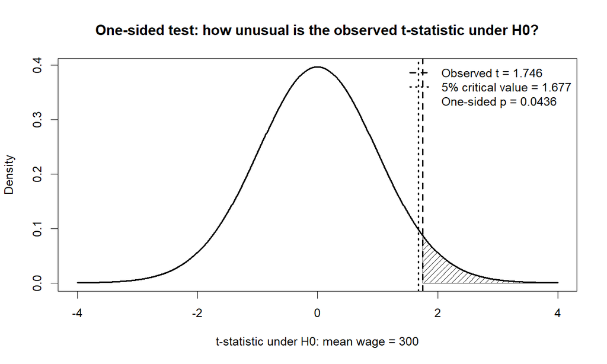

The shaded right tail is the one-sided probability beyond the observed statistic under the null hypothesis.

**Interpretation:** Under the null model, a statistic at least this favorable to the specified alternative would be relatively unusual.

**Decision:** At $\alpha=0.05$, reject $H_0:\mu\leq300$ in favor of $H_1:\mu>300$.

### Lab Step 3 — The 5% threshold is a decision rule, not a law of nature

**Question:** Does the evidence itself change when we choose a different significance level?

We have $p=0.0436$. Predict the decision at $\alpha=0.10$, $0.05$, and $0.01$ before running the code.

**R action:**

```r
p_value <= 0.10
p_value <= 0.05
p_value <= 0.01
```

| Significance level | Decision |
| --- | --- |
| 10% | Reject $H_0$ |
| 5% | Reject $H_0$ |
| 1% | Do not reject $H_0$ |

**Interpretation:** The data and $p$-value have not changed. Only the threshold for action has changed.

**Discussion:** Is $p=0.049$ fundamentally different evidence from $p=0.051$?

**Decision:** Treat the $p$-value as continuous evidence and the significance threshold as a decision rule—not as a boundary between truth and falsehood.

### Lab Step 4 — Deliberate failure: the confidence-interval “paradox”

Lecture 03 gave the 95% **two-sided** confidence interval

$$[296.16,\;354.69].$$

NOK 300 lies inside it.

A student says: **“If 300 is inside the 95% confidence interval, it cannot possibly be rejected at the 5% level.”** Is that always correct?

The statement is correct only for the corresponding **two-sided** 5% test.

For

$$H_1:\mu\neq300,$$

the same $t$-statistic produces

$$p_{two}=0.0871,$$

so we do **not** reject at 5%.

For

$$H_1:\mu>300,$$

the one-sided result remains

$$p_{one}=0.0436,$$

so we reject at 5%.

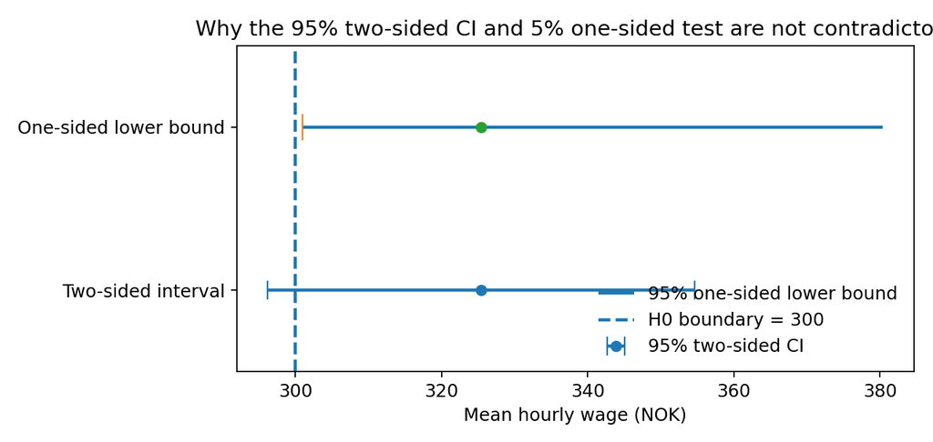

The two-sided 95% interval includes 300, while the corresponding one-sided 95% lower bound lies just above 300.

The matching 95% one-sided lower confidence bound is

$$301.01.$$

**Important**

Resolution

There is no contradiction. A 95% **two-sided** interval corresponds to a 5% **two-sided** test. Today’s economic question is directional, so the relevant 5% test is **one-sided**.

### Lab Step 5 — Deliberate failure: choose the tail after seeing the estimate

An analyst says:

> “The sample mean is above 300, so I decided to use a right-tailed test.”

**Audit the reasoning:** Is the observed sign of $\bar w-300$ a valid reason for choosing $H_1:\mu>300$?

**No.** The alternative must come from the research question.

If management had originally asked

> Has the mean wage **changed in either direction** from 300?

then the correct alternative remains

$$H_1:\mu\neq300,$$

even after seeing a sample mean above 300.

**Decision:** Tail choice is part of model/specification discipline. Do not make the inferential question easier after looking at the answer.

### Lab Step 6 — Type I error, Type II error, and power

For this step, use a normally distributed teaching population with the same scale, $\sigma=105$, so the textbook $t$-test assumptions are represented cleanly.

#### A. Type I error

**Question:** If $H_0$ is actually true, will a 5% test ever reject it?

Predict the rejection rate if we repeat a valid 5% test 10,000 times under $\mu=300$.

**R action:**

```r
null_samples <- simulate_normal_samples(
  n = 50, B = 10000, seed = 51050,
  mu = 300, sigma = 105
)

null_t <- sample_t_statistics(null_samples, mu0 = 300)
mean(null_t >= qt(0.95, df = 49))
```

**Result:** approximately

$$0.0493.$$

So even when the null is true, a 5% procedure deliberately tolerates roughly a 5% chance of rejecting it.

#### B. Power and Type II error

Now suppose the true population mean is actually

$$\mu=325.$$

The true economic difference remains NOK 25/hour. Only the sample size changes.

| $N$ | Simulated probability of rejecting $H_0$ |
| --- | --- |
| 20 | 0.272 |
| 50 | 0.514 |
| 200 | 0.951 |

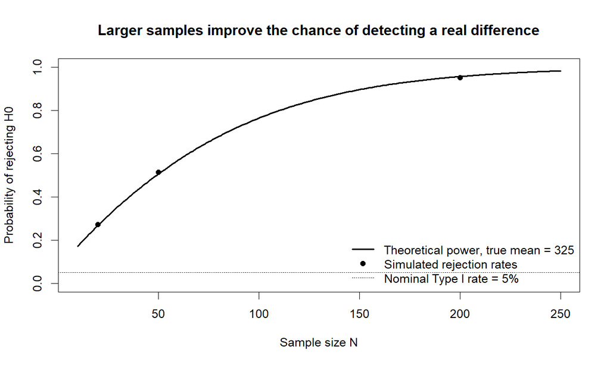

Power increases with sample size even though the true economic difference is unchanged.

**Interpretation:** Larger samples reduce Type II error and increase the probability of detecting a real departure from the null.

**Decision:** “Not statistically significant” does not automatically mean “no effect.” Low power can also arise from limited data or noisy measurement.

### Optional 60-second extension — statistical versus economic significance

Suppose instead that

$$N=50{,}000$$

and the estimated mean is

$$\bar w=300.80.$$

## 4. The AI Audit

### Prompt to give an LLM

> A firm budgets skilled labour at NOK 300 per hour. A random sample of 50 workers gives a mean hourly wage of NOK 325.42 and a sample standard deviation of NOK 102.98.

> Management wants to know whether the true population mean wage is greater than NOK 300 per hour.

> Formulate the null and alternative hypotheses, conduct the appropriate hypothesis test at the 5% significance level, calculate and interpret the p-value, and explain whether the firm’s budgeting assumption should be revised.

### Audit framework

Students should evaluate the answer, not merely compare arithmetic.

1. **Hypotheses:** Does it preserve the directional economic question?
2. **Standard error:** Does it use $s/\sqrt N$ rather than $s$?
3. **Tail:** Does $H_1:\mu>300$ lead to the right tail?
4. **$p$-value interpretation:** Does it avoid claiming that $p$ is $P(H_0\text{ true})$?
5. **Conclusion:** Does it say “evidence against $H_0$” rather than “proof”?
6. **Managerial inference:** Does it distinguish statistical evidence from whether revising the budget is economically worthwhile?

**Warning**

Likely AI failure worth looking for

An LLM may calculate everything correctly but say something like **“there is a 4.4% probability that the null hypothesis is true”** or **“there is a 4.4% chance this occurred by chance.”** The arithmetic can be right while the inferential interpretation is wrong.

### Future-proof follow-up prompt

> The 95% two-sided confidence interval from the same data is approximately [296.16, 354.69], so NOK 300 lies inside the interval. Yet the one-sided hypothesis test above rejects $H_0:\mu\leq300$ at the 5% level.

> Explain why these two results are not contradictory. Then state which confidence interval or confidence bound corresponds to the one-sided 5% test.

### Second stress-test

> An analyst says: “Because the observed sample mean is above 300, I decided to use a one-sided alternative $H_1:\mu>300$, which gave statistical significance. A two-sided test would not have been significant.” Evaluate whether this is valid inferential reasoning.

The strongest answer explains that a directional alternative is legitimate only when justified by the substantive question independently of the observed result.

## 5. Exit Problem

A seafood processor claims that the average weight of its salmon fillets is 500 g. A quality-control researcher suspects the actual mean is **below** 500 g.

A random sample gives

$$N=36,
\qquad
\bar y=492,
\qquad
s=24.$$

**Questions**

1. State $H_0$ and $H_1$.
2. Calculate the test statistic.
3. Should the $p$-value come from the left tail, right tail, or two tails?
4. What would “do not reject $H_0$” mean?

### Expected answer

**TipClick to view Answer**

$$H_0:\mu\geq500,
\qquad
H_1:\mu<500.$$

The standard error is

$$se=\frac{24}{\sqrt{36}}=4,$$

so

$$t=\frac{492-500}{4}=-2.$$

Because the alternative is $\mu<500$, use the **left tail**. The $p$-value is about 0.027, so reject at the 5% level.

### What important wrong answers reveal

- **Uses two tails because $t=-2$:** confuses the sign of the statistic with the substantive alternative.
- **Says failure to reject would prove $\mu=500$:** confuses compatibility with proof.
- **Interprets $p$ as the probability that $H_0$ is true:** reverses the conditional logic of the test.

## Assessment connection

### Scenario

A municipality claims that the mean waiting time for building-permit applications is no more than

$$30\text{ days}.$$

A researcher randomly samples

$$N=64$$

completed applications and finds

$$\bar y=33.0,
\qquad
s=12.0.$$

### Part A — Closed-book / individual reasoning

**Question 1.** Formulate the appropriate null and alternative hypotheses.

**Solution:**

$$H_0:\mu\leq30,
\qquad
H_1:\mu>30.$$

**Question 2.** Calculate the standard error and $t$-statistic.

**Solution:**

$$se=\frac{12}{\sqrt{64}}=1.5,$$

and

$$t=\frac{33-30}{1.5}=2.$$

**Question 3.** Interpret $t=2$.

**Solution:** The observed sample mean is two estimated standard errors above the null boundary of 30 days.

**Question 4.** Suppose the one-sided $p$-value is 0.025. What is the decision at $\alpha=.05$ and at $\alpha=.01$? Has the evidence itself changed?

**Solution:** Reject at 5%; do not reject at 1%. The evidence is the same; only the decision threshold has changed.

### Part B — Open-book / AI-allowed

Two reports evaluate whether municipal permit processing exceeds the official 30-day target.

**Report A**

$$N=64,\qquad
\bar y=33,\qquad
s=12,\qquad
p=0.025.$$

**Report B**

$$N=10{,}000,\qquad
\bar y=30.4,\qquad
s=12,\qquad
p<0.001.$$

An AI assistant concludes:

> “Report B provides much stronger evidence of a serious administrative problem because its p-value is much smaller.”

**Evaluate this conclusion.**

Your answer should distinguish:

- strength of statistical evidence;
- magnitude of the estimated deviation;
- the role of sample size;
- economic/practical importance;
- what additional information would matter for the policy decision.

#### Short grading rubric

- **Insufficient:** Ranks the two reports only by $p$-value.
- **Competent:** Recognizes that Report B gives stronger statistical evidence but that its estimated excess is only 0.4 day versus 3 days in Report A.
- **Strong:** Clearly separates **strength of evidence**, **effect magnitude**, and **practical importance**, and explains why a very large sample can make a substantively tiny difference highly statistically significant.

## What comes next

We now have the core inferential language needed for regression output:

$$\boxed{
\text{estimate}
\;\rightarrow\;
\text{standard error}
\;\rightarrow\;
t
\;\rightarrow\;
p
\;\rightarrow\;
\text{justified conclusion}
}$$

In later regression models the parameter will no longer be only a population mean. The same logic will be applied to coefficients such as $\beta_1$ and $\beta_2$.

**Important**

Take-home idea

**Statistical evidence is the size of a discrepancy relative to its sampling uncertainty—not simply whether two numbers are different.**

And the hypothesis must come from the economic question **before** the data determine the answer.

## Instructor notes

**Instructor-only guidance**

**Likely misconceptions**

- The $p$-value is the probability that $H_0$ is true.
- A 5% significance result means there is a 5% probability the finding is “due to chance.”
- A one-sided test can be chosen after seeing the sign of the estimate.
- Failure to reject means the null is true.
- $p=.049$ is fundamentally different evidence from $p=.051$.
- A smaller $p$-value automatically means a larger or more important effect.
- A 95% confidence interval must agree with every 5% hypothesis test, regardless of whether the test is one- or two-sided.

**Where discussion may run long**

The confidence-interval “paradox” is worth protecting. It connects the two lectures and forces students to distinguish the substantive question from the mechanical calculation. The Type I/II simulation can be shortened if this discussion is productive.

**If time is short**

Keep Steps 1–5. For Step 6, show only the power figure and state the Type I result. The optional statistical-versus-economic-significance example can be moved to the assessment discussion.

**Questions if the class is quiet**

- Would you make the same decision if the standard error were twice as large?
- Who decided that the alternative should be $\mu>300$ rather than $\mu\neq300$?
- If $p=.0436$, what exactly would become different if I changed $\alpha$ from .05 to .01?
- Can a true null hypothesis be rejected? How often should that happen in a 5% test?
- Can a very small effect be highly statistically significant?

**Likely AI-generated answers**

An LLM will probably calculate the one-sided $t$-test correctly. Push students toward interpretive errors: probability of the null, “due to chance,” post-hoc tail selection, and automatic managerial conclusions from statistical significance.

**Numerical points to have ready**

- One-sided: $t=1.7457$, $p=0.0436$, reject at 5% but not at 1%.
- Two-sided: $p=0.0871$, do not reject at 5%.
- 95% two-sided CI: $[296.16,354.69]$.
- 95% one-sided lower bound: $301.01$.
- Repeated normal-model Type I rejection rate in the fixed simulation: 0.0493.
- Simulated power for true $\mu=325$: 0.272 ($N=20$), 0.514 ($N=50$), 0.951 ($N=200$).

**Single most important idea**

A hypothesis test asks whether the observed discrepancy is large **relative to sampling uncertainty under a stated null**, and the economic question—not the observed data—must determine what discrepancy matters.